# Anna Dziuba: Covid Effects on Mental State

Author

Reinhold Kliegl

Published

September 17, 2022

# 1 Background

- Forschungsfrage: Gibt es mittelfristige Auswirkungen der COVID-19-Pandemie auf das psychische Befinden bei Erwachsenen ab 35 Jahren (Bürger*innen im mittleren und hohen Erwachsenenalter der Gemeinde Bad Schönborn)?
- Psychisches Befinden gemessen am Kohärenzsinn, seelischen Gesundheit sowie der Zufriedenheit mit dem Leben und der Gesundheit
- Der Datensatz besteht aus 6 Messzeitpunkte mit Längsschnittprobanden und neuen Querschnittsprobanden zu fast jedem Messzeitpunkt

# 2 Preprocessing

## 2.1 RK style guide

- Random factors should be factors, not integers!
- Factors capitalized, continuous variables in lower case
- `Subj` instead of `ID`; prefix subject and item numbers with `S` and `I`
- Short variable names and factor levels, but respect tradeoff with mmemonic value
- Labels should be of equal length
- Hint: Leave out vowels in names and labels
- See Jenny Bryan’s [Naming Things](https://docplayer.net/55248970-Naming-things-prepared-by-jenny-bryan-for-reproducible-science-workshop.html)

## 2.2 Packages

```r
library(easystats)
library(tidyverse)
library(haven)
library(labelled)
library(lme4)
library(summarytools)
# respecting color vision deficiency
cbPalette <- c( "#0072B2", "#D55E00", "#009E73", "#CC79A7",
                "#F0E442", "#56B4E9", "#999999", "#E69F00")
```

## 2.3 Read and transform data

- Missing SES to level 3 – most frequent one

```r
data <-
   read_sav("DZIUBA.sav") |>
   remove_labels() |>
   select(Subj=1, Sex=2, SES=3, covidPsych=22, 4:9, 23:46) |>
   mutate( Subj = factor(paste0("S", str_pad(as.character(Subj), width = 4, side = "left", pad = "0"))),
           Sex = factor(Sex, levels=0:1, labels=c("female", "male")),
           SES = ifelse(is.na(SES), 3, SES),
           SES = factor(SES)
)

colnames(data) <-  gsub("Alter", "Age", colnames(data))
colnames(data) <-  gsub("Zufriedenheit_Leben", "Life", colnames(data))
colnames(data) <-  gsub("Zufriedenheit_Gesundheit", "Health", colnames(data))
stview(dfSummary(data))
```

```
Switching method to 'browser'
```

```
Output file written: /var/folders/nd/l59kkqd951xdb29k4rt4yzj80000gn/T//Rtmpr3EY5U/file512b5923f1d9.html
```

## 2.4 Subject

```r
dat_subj <-
  data |>
  select(1:3, 5:10) |>
  pivot_longer(4:9, names_prefix="Age_", names_to="year",
               values_to= "age", values_drop_na=TRUE,
               names_transform=list(year=as.integer),) |>
   mutate(year = ifelse(year>90, year+1900, year+2000)) |>
   select(Subj, year, Sex, SES, age)

stview(dfSummary(dat_subj))
```

```
Switching method to 'browser'
```

```
Output file written: /var/folders/nd/l59kkqd951xdb29k4rt4yzj80000gn/T//Rtmpr3EY5U/file512b79e8fb4f.html
```

## 2.5 Measures

```r
dat_msrs <-
  data |>
  select(1, 11:34) |>
  pivot_longer(2:25, names_to=c("Measure", "year"), names_sep="_",
               names_transform=list(Measure=as.factor, year=as.integer),
               values_to="score", values_drop_na=TRUE) |>
  mutate(year = ifelse(year>90, year+1900, year+2000)) |>
  group_by(Measure) %>%
  mutate(zScoreA  = as.numeric(scale(score)),
         zBound30 = ifelse(abs(zScoreA) < 3.0, TRUE, FALSE)) %>%
  filter(zBound30) %>%
  group_by(Measure) |>
  mutate(zScore = as.numeric(scale(score))) |>
  ungroup() |>
  select(Subj, year, Measure, zScore)

stview(dfSummary(dat_msrs))
```

```
Switching method to 'browser'
```

```
Output file written: /var/folders/nd/l59kkqd951xdb29k4rt4yzj80000gn/T//Rtmpr3EY5U/file512b469119fc.html
```

## 2.6 Combine

```r
dat <-
  dat_msrs |>
  left_join(dat_subj, by=c("Subj", "year")) |>
  relocate(Sex:age, .after=Subj)

stview(dfSummary(dat))
```

```
Switching method to 'browser'
```

```
Output file written: /var/folders/nd/l59kkqd951xdb29k4rt4yzj80000gn/T//Rtmpr3EY5U/file512b1de29fef.html
```

# 3 Plots

## 3.1 Zero-order year effects

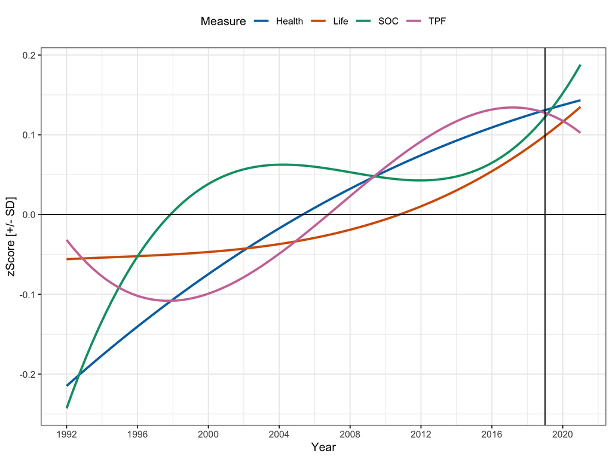

```r
dat |>
  ggplot(aes(x=year, y=zScore, group=Measure, color=Measure)) +
  geom_smooth(method="lm", formula=y~poly(x,3), se=FALSE) +
  scale_x_continuous("Year", breaks=seq(1992,2022,4)) +
  scale_y_continuous("zScore [+/- SD]") +
  scale_colour_manual("Measure", values=cbPalette) +
  geom_hline(yintercept=0) + geom_vline(xintercept=2019) +
  theme_bw() + theme(legend.position="top")
```

## 3.2 Zero-order age effects

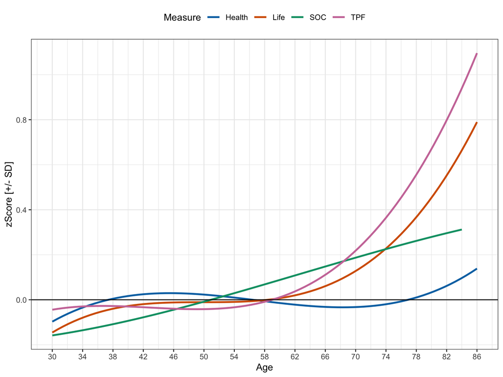

```r
dat |>
  ggplot(aes(x=age, y=zScore, group=Measure, color=Measure)) +
  geom_smooth(method="lm", formula=y~poly(x,3), se=FALSE) +
  scale_x_continuous("Age", breaks=seq(30,86,4)) +
  scale_y_continuous("zScore [+/- SD]") +
  scale_colour_manual("Measure", values=cbPalette) +
  geom_hline(yintercept=0) +
  theme_bw() + theme(legend.position="top")
```

# 4 Linear mixed models

## 4.1 Contrasts and trends

```r
contrasts(dat$Sex) <- contr.sum(2)
contrasts(dat$Sex) <- contr.sum(2)
```

## 4.2 *A priori* LMM

```r
dat$a1 <- dat$age - 55
dat$a2 <- dat$a1*dat$a1
dat$y1 <- dat$year - 2006.5
dat$y2 <- dat$y1*dat$y1

m1 <- lmer(zScore ~ 1 + (Measure+Sex)/(y1+y2+a1+a2) + (1 | Subj), data=dat,
           REML=FALSE, control=lmerControl(calc.derivs=FALSE))
print(summary(m1), corr=FALSE)
```

```
Linear mixed model fit by maximum likelihood  ['lmerMod']
Formula: zScore ~ 1 + (Measure + Sex)/(y1 + y2 + a1 + a2) + (1 | Subj)
   Data: dat
Control: lmerControl(calc.derivs = FALSE)

     AIC      BIC   logLik deviance df.resid
 22263.5  22539.9 -11092.7  22185.5     8814

Scaled residuals:
    Min      1Q  Median      3Q     Max
-4.8880 -0.5717  0.0106  0.6347  4.1067

Random effects:
 Groups   Name        Variance Std.Dev.
 Subj     (Intercept) 0.4658   0.6825
 Residual             0.5708   0.7555
Number of obs: 8853, groups:  Subj, 1064

Fixed effects:
                             Estimate Std. Error t value
(Intercept)                -5.707e-02  3.890e-02  -1.467
MeasureLife                -4.145e-02  4.216e-02  -0.983
MeasureSOC                  8.308e-02  4.249e-02   1.955
MeasureTPF                 -6.209e-02  4.323e-02  -1.436
Sex1                       -4.346e-02  2.902e-02  -1.498
MeasureHealth:Sexfemale:y1  1.067e-02  3.550e-03   3.006
MeasureLife:Sexfemale:y1    2.058e-04  3.258e-03   0.063
MeasureSOC:Sexfemale:y1     1.060e-02  3.270e-03   3.240
MeasureTPF:Sexfemale:y1     6.273e-03  3.348e-03   1.874
MeasureHealth:Sexmale:y1    1.483e-02  3.881e-03   3.821
MeasureLife:Sexmale:y1      3.950e-03  3.609e-03   1.095
MeasureSOC:Sexmale:y1       4.603e-03  3.644e-03   1.263
MeasureTPF:Sexmale:y1       1.588e-03  3.690e-03   0.430
MeasureHealth:Sexfemale:y2  1.375e-04  3.024e-04   0.455
MeasureLife:Sexfemale:y2    7.619e-04  2.630e-04   2.897
MeasureSOC:Sexfemale:y2    -7.539e-04  2.681e-04  -2.812
MeasureTPF:Sexfemale:y2    -2.582e-05  2.790e-04  -0.093
MeasureHealth:Sexmale:y2   -1.143e-04  3.091e-04  -0.370
MeasureLife:Sexmale:y2      1.629e-04  2.665e-04   0.611
MeasureSOC:Sexmale:y2       1.746e-04  2.721e-04   0.642
MeasureTPF:Sexmale:y2       1.080e-03  2.802e-04   3.856
MeasureHealth:Sexfemale:a1 -3.309e-03  3.520e-03  -0.940
MeasureLife:Sexfemale:a1    3.413e-03  3.509e-03   0.973
MeasureSOC:Sexfemale:a1     8.704e-03  3.662e-03   2.377
MeasureTPF:Sexfemale:a1     4.174e-03  3.897e-03   1.071
MeasureHealth:Sexmale:a1   -1.067e-02  3.590e-03  -2.973
MeasureLife:Sexmale:a1      6.360e-03  3.577e-03   1.778
MeasureSOC:Sexmale:a1       1.164e-03  3.688e-03   0.316
MeasureTPF:Sexmale:a1       5.379e-03  3.667e-03   1.467
MeasureHealth:Sexfemale:a2 -4.816e-05  1.853e-04  -0.260
MeasureLife:Sexfemale:a2    7.770e-05  1.798e-04   0.432
MeasureSOC:Sexfemale:a2     4.041e-04  1.880e-04   2.149
MeasureTPF:Sexfemale:a2     5.766e-05  2.035e-04   0.283
MeasureHealth:Sexmale:a2   -1.864e-04  1.665e-04  -1.120
MeasureLife:Sexmale:a2      1.021e-04  1.603e-04   0.637
MeasureSOC:Sexmale:a2      -4.166e-04  1.698e-04  -2.453
MeasureTPF:Sexmale:a2       5.332e-04  1.667e-04   3.199
```

Let’s check whether there are specific COVID effects in 2021

```r
dat$covid <- ifelse(dat$year==2021, 1, 0)

m2 <- lmer(zScore ~ 1 + (Measure+Sex)/(y1+y2+(a1+a2)*covid) + (1 | Subj), data=dat,
           REML=FALSE, control=lmerControl(calc.derivs=FALSE))
print(summary(m2), corr=FALSE)
```

```
Linear mixed model fit by maximum likelihood  ['lmerMod']
Formula: zScore ~ 1 + (Measure + Sex)/(y1 + y2 + (a1 + a2) * covid) +
    (1 | Subj)
   Data: dat
Control: lmerControl(calc.derivs = FALSE)

     AIC      BIC   logLik deviance df.resid
 22250.3  22696.8 -11062.1  22124.3     8790

Scaled residuals:
    Min      1Q  Median      3Q     Max
-4.6547 -0.5719  0.0103  0.6360  4.1128

Random effects:
 Groups   Name        Variance Std.Dev.
 Subj     (Intercept) 0.4643   0.6814
 Residual             0.5666   0.7527
Number of obs: 8853, groups:  Subj, 1064

Fixed effects:
                                   Estimate Std. Error t value
(Intercept)                      -4.424e-02  4.154e-02  -1.065
MeasureLife                      -4.091e-02  4.616e-02  -0.886
MeasureSOC                        1.104e-01  4.633e-02   2.384
MeasureTPF                       -7.650e-02  4.716e-02  -1.622
Sex1                             -5.092e-02  2.986e-02  -1.705
MeasureHealth:Sexfemale:y1        1.943e-02  4.700e-03   4.134
MeasureLife:Sexfemale:y1          2.828e-03  4.689e-03   0.603
MeasureSOC:Sexfemale:y1           3.453e-03  4.706e-03   0.734
MeasureTPF:Sexfemale:y1           8.535e-03  4.855e-03   1.758
MeasureHealth:Sexmale:y1          1.377e-02  5.226e-03   2.635
MeasureLife:Sexmale:y1            9.255e-04  5.230e-03   0.177
MeasureSOC:Sexmale:y1            -3.250e-03  5.243e-03  -0.620
MeasureTPF:Sexmale:y1             1.089e-02  5.301e-03   2.055
MeasureHealth:Sexfemale:y2        1.063e-03  5.057e-04   2.102
MeasureLife:Sexfemale:y2          8.920e-04  4.349e-04   2.051
MeasureSOC:Sexfemale:y2          -1.624e-03  4.367e-04  -3.719
MeasureTPF:Sexfemale:y2           1.520e-04  4.462e-04   0.341
MeasureHealth:Sexmale:y2         -6.320e-04  5.135e-04  -1.231
MeasureLife:Sexmale:y2           -3.997e-04  4.400e-04  -0.908
```

[output cut: 27 more lines]

```
MeasureLife:Sexfemale:a1:covid    6.764e-03  6.827e-03   0.991
MeasureSOC:Sexfemale:a1:covid    -5.844e-04  7.112e-03  -0.082
MeasureTPF:Sexfemale:a1:covid     1.523e-02  7.707e-03   1.976
MeasureHealth:Sexmale:a1:covid    2.101e-02  7.486e-03   2.807
MeasureLife:Sexmale:a1:covid      1.283e-02  7.663e-03   1.674
MeasureSOC:Sexmale:a1:covid       1.429e-02  7.870e-03   1.816
MeasureTPF:Sexmale:a1:covid       7.566e-03  7.981e-03   0.948
MeasureHealth:Sexfemale:a2:covid  1.009e-03  4.749e-04   2.124
MeasureLife:Sexfemale:a2:covid    8.743e-05  4.883e-04   0.179
MeasureSOC:Sexfemale:a2:covid    -5.990e-04  4.937e-04  -1.213
MeasureTPF:Sexfemale:a2:covid     1.096e-03  5.435e-04   2.017
MeasureHealth:Sexmale:a2:covid    6.872e-05  4.220e-04   0.163
MeasureLife:Sexmale:a2:covid     -2.520e-04  4.256e-04  -0.592
MeasureSOC:Sexmale:a2:covid       1.031e-05  4.704e-04   0.022
MeasureTPF:Sexmale:a2:covid      -1.530e-04  4.497e-04  -0.340
```

```r
anova(m1, m2)
```

```
Data: dat
Models:
m1: zScore ~ 1 + (Measure + Sex)/(y1 + y2 + a1 + a2) + (1 | Subj)
m2: zScore ~ 1 + (Measure + Sex)/(y1 + y2 + (a1 + a2) * covid) + (1 | Subj)
   npar   AIC   BIC logLik deviance  Chisq Df Pr(>Chisq)
m1   39 22264 22540 -11093    22186
m2   63 22250 22697 -11062    22124 61.192 24  4.328e-05 ***
---
Signif. codes:  0 '***' 0.001 '**' 0.01 '*' 0.05 '.' 0.1 ' ' 1
```

```r
m3 <- lmer(zScore ~ 1 + (Measure*Sex)/(y1+y2+(a1+a2)*covid) + (1 | Subj), data=dat,
           REML=FALSE, control=lmerControl(calc.derivs=FALSE))
print(summary(m2), corr=FALSE)
```

```
Linear mixed model fit by maximum likelihood  ['lmerMod']
Formula: zScore ~ 1 + (Measure + Sex)/(y1 + y2 + (a1 + a2) * covid) +
    (1 | Subj)
   Data: dat
Control: lmerControl(calc.derivs = FALSE)

     AIC      BIC   logLik deviance df.resid
 22250.3  22696.8 -11062.1  22124.3     8790

Scaled residuals:
    Min      1Q  Median      3Q     Max
-4.6547 -0.5719  0.0103  0.6360  4.1128

Random effects:
 Groups   Name        Variance Std.Dev.
 Subj     (Intercept) 0.4643   0.6814
 Residual             0.5666   0.7527
Number of obs: 8853, groups:  Subj, 1064

Fixed effects:
                                   Estimate Std. Error t value
(Intercept)                      -4.424e-02  4.154e-02  -1.065
MeasureLife                      -4.091e-02  4.616e-02  -0.886
MeasureSOC                        1.104e-01  4.633e-02   2.384
MeasureTPF                       -7.650e-02  4.716e-02  -1.622
Sex1                             -5.092e-02  2.986e-02  -1.705
MeasureHealth:Sexfemale:y1        1.943e-02  4.700e-03   4.134
MeasureLife:Sexfemale:y1          2.828e-03  4.689e-03   0.603
MeasureSOC:Sexfemale:y1           3.453e-03  4.706e-03   0.734
MeasureTPF:Sexfemale:y1           8.535e-03  4.855e-03   1.758
MeasureHealth:Sexmale:y1          1.377e-02  5.226e-03   2.635
MeasureLife:Sexmale:y1            9.255e-04  5.230e-03   0.177
MeasureSOC:Sexmale:y1            -3.250e-03  5.243e-03  -0.620
MeasureTPF:Sexmale:y1             1.089e-02  5.301e-03   2.055
MeasureHealth:Sexfemale:y2        1.063e-03  5.057e-04   2.102
MeasureLife:Sexfemale:y2          8.920e-04  4.349e-04   2.051
MeasureSOC:Sexfemale:y2          -1.624e-03  4.367e-04  -3.719
MeasureTPF:Sexfemale:y2           1.520e-04  4.462e-04   0.341
MeasureHealth:Sexmale:y2         -6.320e-04  5.135e-04  -1.231
MeasureLife:Sexmale:y2           -3.997e-04  4.400e-04  -0.908
```

[output cut: 27 more lines]

```
MeasureLife:Sexfemale:a1:covid    6.764e-03  6.827e-03   0.991
MeasureSOC:Sexfemale:a1:covid    -5.844e-04  7.112e-03  -0.082
MeasureTPF:Sexfemale:a1:covid     1.523e-02  7.707e-03   1.976
MeasureHealth:Sexmale:a1:covid    2.101e-02  7.486e-03   2.807
MeasureLife:Sexmale:a1:covid      1.283e-02  7.663e-03   1.674
MeasureSOC:Sexmale:a1:covid       1.429e-02  7.870e-03   1.816
MeasureTPF:Sexmale:a1:covid       7.566e-03  7.981e-03   0.948
MeasureHealth:Sexfemale:a2:covid  1.009e-03  4.749e-04   2.124
MeasureLife:Sexfemale:a2:covid    8.743e-05  4.883e-04   0.179
MeasureSOC:Sexfemale:a2:covid    -5.990e-04  4.937e-04  -1.213
MeasureTPF:Sexfemale:a2:covid     1.096e-03  5.435e-04   2.017
MeasureHealth:Sexmale:a2:covid    6.872e-05  4.220e-04   0.163
MeasureLife:Sexmale:a2:covid     -2.520e-04  4.256e-04  -0.592
MeasureSOC:Sexmale:a2:covid       1.031e-05  4.704e-04   0.022
MeasureTPF:Sexmale:a2:covid      -1.530e-04  4.497e-04  -0.340
```

```r
anova(m1, m2, m3)
```

```
Data: dat
Models:
m1: zScore ~ 1 + (Measure + Sex)/(y1 + y2 + a1 + a2) + (1 | Subj)
m2: zScore ~ 1 + (Measure + Sex)/(y1 + y2 + (a1 + a2) * covid) + (1 | Subj)
m3: zScore ~ 1 + (Measure * Sex)/(y1 + y2 + (a1 + a2) * covid) + (1 | Subj)
   npar   AIC   BIC logLik deviance  Chisq Df Pr(>Chisq)
m1   39 22264 22540 -11093    22186
m2   63 22250 22697 -11062    22124 61.192 24  4.328e-05 ***
m3   66 22228 22696 -11048    22096 28.171  3  3.344e-06 ***
---
Signif. codes:  0 '***' 0.001 '**' 0.01 '*' 0.05 '.' 0.1 ' ' 1
```

# 5 Appendix